# A Myb-dominated gene regulatory network universally controls sexual cell fate transitions in diatoms

Gust Bilcke

Abstract

Single-cell transcriptomic analyses that recreate key results and figures from: A Myb-dominated gene regulatory network universally controls sexual cell fate transitions in diatoms

# Continuous light (LL) experiments

## Download Seurat object from NCBI GEO

```{bash; eval = FALSE}

cd data/ wget https://ftp.ncbi.nlm.nih.gov/geo/series/GSE303nnn/GSE303315/suppl/GSE303315%5FseuratObj%5Ffor%5Fpublication%2Erds

````
## Load Seurat object & get statistics


``` r
# Required packages
library(slingshot); library(RColorBrewer); library(viridis); library(UCell); library(Seurat); library(openxlsx); library(ggplot2); library(paletteer); library(tradeSeq); library(dplyr); library(tidyr); library(ggnewscale); library(cowplot);  library(ggridges); library(clusterProfiler); library(ggbump)
````

```r
# Seurat object (continuous light)
seuratObj <- readRDS("../data/GSE303315_seuratObj_for_publication.rds" )

# Number of cells
table(seuratObj@meta.data$Cluster)
```

```
##
##    1    2    3    4    5    6    7    8    9   10   11   12   13   14   15   16
##  288  831   70  443  648  202  166  400  274  342  536 1431 1095  717  349  882
```

```r
table(seuratObj$Sample)
```

```
##
##  T12  T19  T24
## 1079 3448 4147
```

```r
length(seuratObj$Sample)
```

```
## [1] 8674
```

```r
# Number of UMIs per cell
mean(seuratObj$nCount_RNA)
```

```
## [1] 2035.108
```

```r
mean(seuratObj$nCount_RNA[seuratObj$Sample == "T12"])
```

```
## [1] 1738.704
```

```r
mean(seuratObj$nCount_RNA[seuratObj$Sample == "T19"])
```

```
## [1] 2458.799
```

```r
mean(seuratObj$nCount_RNA[seuratObj$Sample == "T24"])
```

```
## [1] 1759.953
```

```r
# Total number of UMIs
sum(seuratObj$nCount_RNA)
```

```
## [1] 17652525
```

```r
sum(seuratObj$nCount_RNA[seuratObj$Sample == "T12"])
```

```
## [1] 1876062
```

```r
sum(seuratObj$nCount_RNA[seuratObj$Sample == "T19"])
```

```
## [1] 8477939
```

```r
sum(seuratObj$nCount_RNA[seuratObj$Sample == "T24"])
```

```
## [1] 7298524
```

```r
# total Number of genes expressed (per set of cells)
RNA_data <- as.data.frame(seuratObj@assays$RNA@data)
expressed <- rowSums(RNA_data)
expressed_T12 <- rowSums(RNA_data[seuratObj$Sample == "T12"])
expressed_T19 <- rowSums(RNA_data[seuratObj$Sample == "T19"])
expressed_T24 <- rowSums(RNA_data[seuratObj$Sample == "T24"])
table(expressed > 0)
```

```
##
##  TRUE
## 20534
```

```r
table(expressed_T12 > 0)
```

```
##
## FALSE  TRUE
##  2507 18027
```

```r
table(expressed_T19 > 0)
```

```
##
## FALSE  TRUE
##   296 20238
```

```r
table(expressed_T24 > 0)
```

```
##
## FALSE  TRUE
##  1163 19371
```

```r
# average number of genes expressed / cell
expr_vector <- colSums(RNA_data > 0)
mean(expr_vector)
```

```
## [1] 1196.126
```

```r
mean(expr_vector[seuratObj$Sample == "T12"])
```

```
## [1] 1043.624
```

```r
mean(expr_vector[seuratObj$Sample == "T19"])
```

```
## [1] 1391.878
```

```r
mean(expr_vector[seuratObj$Sample == "T24"])
```

```
## [1] 1073.048
```

## Annotate UMAP

### Cell cycle phasing

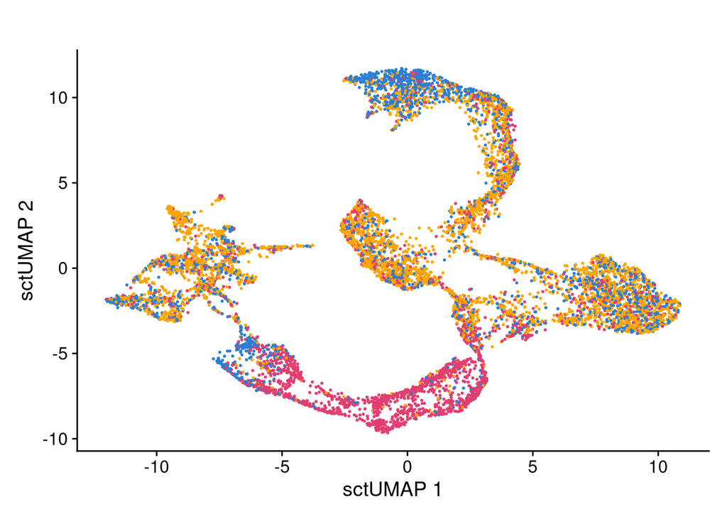

```r
CC <- read.xlsx("../data/cell_cycle_markers_Ccl.xlsx")
seuratObj <- CellCycleScoring(seuratObj, s.features = CC$gene_ID[CC$cell_cycle_stage == "G1 S" | CC$cell_cycle_stage == "S"], CC$gene_ID[CC$cell_cycle_stage == "M"],set.ident = F)

CCcols <- c("orange", "#E33D6F", "#297FD5", "tan")
CC_plot <- DimPlot(seuratObj, reduction="SCT_umap", group.by = "Phase", pt.size=0.22, cols = CCcols) + theme(legend.position = "none")  + labs(title = "")+xlab("sctUMAP 1")+ylab("sctUMAP 2")
CC_plot
```

### Annotate using bulk RNA-seq time series from Audoor et al. (https://onlinelibrary.wiley.com/doi/10.1111/mec.17320)

Plotting the average log2 fold changes of the top-20 top markers for each cluster

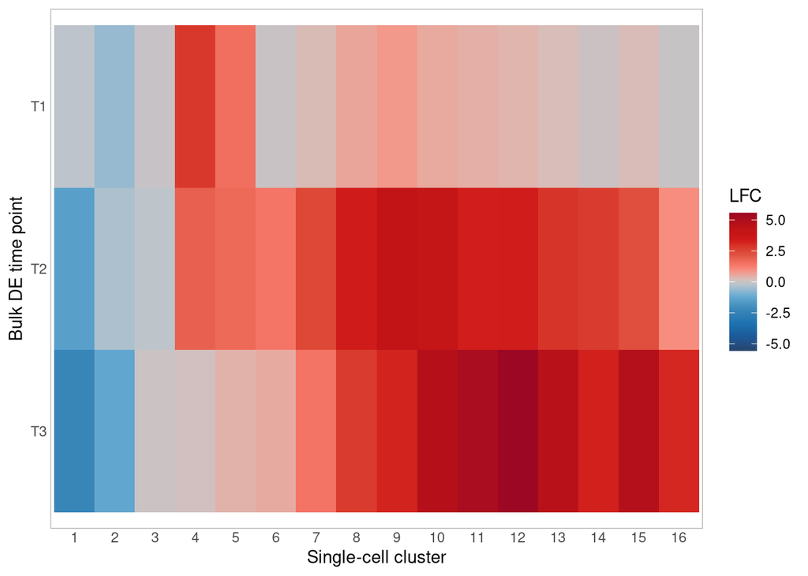

```r
# Load data
results <- read.xlsx("../data/Audoor_results_DE_Ccl.xlsx",1)[c(1,2,3,4)]
results <- results[results$contrast != "overall",]
allmarkers20 <- read.delim("../data/allMarkers20.txt")

# Analyze & plot
clusterlist <- list()
pal <- paletteer_c("ggthemes::Classic Red-Blue", 30)

for (cluster in allmarkers20$cluster){
  allmarkers20$gene2[allmarkers20$cluster == cluster] <- unlist(lapply(allmarkers20$gene[allmarkers20$cluster == cluster], function(x) gsub(x, pattern = "-", replacement = "_")))
  res_sel <- results[results$gene_ID %in% allmarkers20$gene2[allmarkers20$cluster == cluster],]
  res_agg <- aggregate(res_sel$LFC, by = list(res_sel$contrast), "mean")
  res_agg$cluster <- cluster
  clusterlist[[cluster]] <- res_agg
}

clusterexpr <- do.call(rbind, clusterlist)
colnames(clusterexpr) <- c("contrast", "LFC", "cluster")

clusterexpr$cluster <- factor(clusterexpr$cluster, levels = 1:16)
clusterexpr$contrast <- factor(clusterexpr$contrast, levels = c("T3", "T2", "T1"))

ggplot(clusterexpr) +
    geom_tile(aes(x = contrast, y = cluster, fill = LFC)) +
     scale_fill_gradientn(colours = rev(pal), limits = c(-max(abs(clusterexpr$LFC)),max(abs(clusterexpr$LFC))), na.value = "grey40") +
    theme_light() +
    theme(panel.grid = element_blank(), axis.ticks = element_blank()) +
    xlab("Bulk DE time point") +
    ylab("Single-cell cluster") +
  coord_flip()
```

### Annotate SIP (sex-inducing pheromone) response, using bulk RNA-seq data from Belisova, Bilcke et al. 2025 https://nph.onlinelibrary.wiley.com/doi/10.1111/nph.20334

```r
# Load data
SIP_9h <- read.delim("../data/SIP_9h_DE_Belisova2025.txt")
SIP_9h$gene <- unlist(lapply(SIP_9h$gene_ID, function(x) gsub("_", "-", x)))
sip_9hgenes <- SIP_9h$gene[SIP_9h$adjP < 0.05 & SIP_9h$logFC >0]

markers <- read.xlsx("../data/allmarkers_annotated.xlsx")

# Link SIP response to UMAP using UCELL
signatures4 <- list(sip_9hgenes = sip_9hgenes)
seuratObj <- AddModuleScore_UCell(seuratObj, features=signatures4, name = NULL)
```

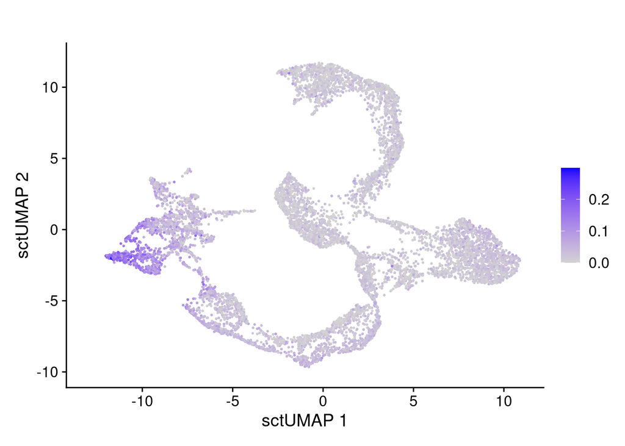

```r
FeaturePlot(seuratObj, reduction="SCT_umap", features = names(signatures4), pt.size=0.22)  + labs(title = "")+xlab("sctUMAP 1")+ylab("sctUMAP 2")
```

### Visualize different annotations on UMAP

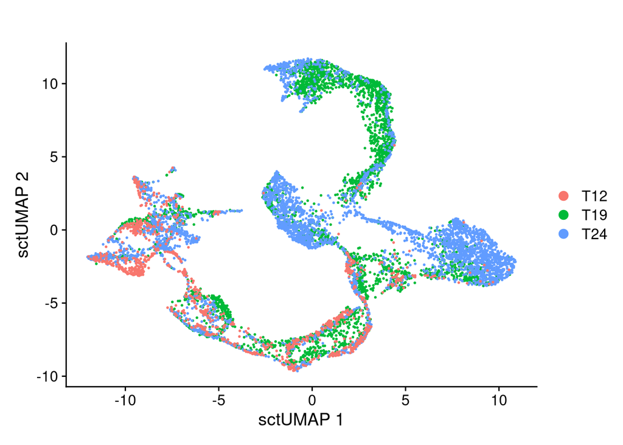

```r
DimPlot(seuratObj, reduction="SCT_umap", group.by = "Sample", pt.size=0.22)+ labs(title = "")+xlab("sctUMAP 1")+ylab("sctUMAP 2")
```

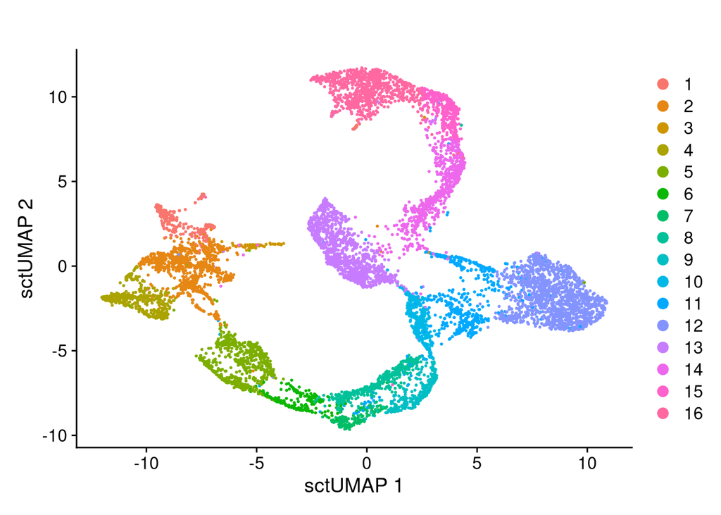

```r
DimPlot(seuratObj, reduction="SCT_umap", group.by = "Cluster", pt.size=0.22)+ labs(title = "")+xlab("sctUMAP 1")+ylab("sctUMAP 2")
```

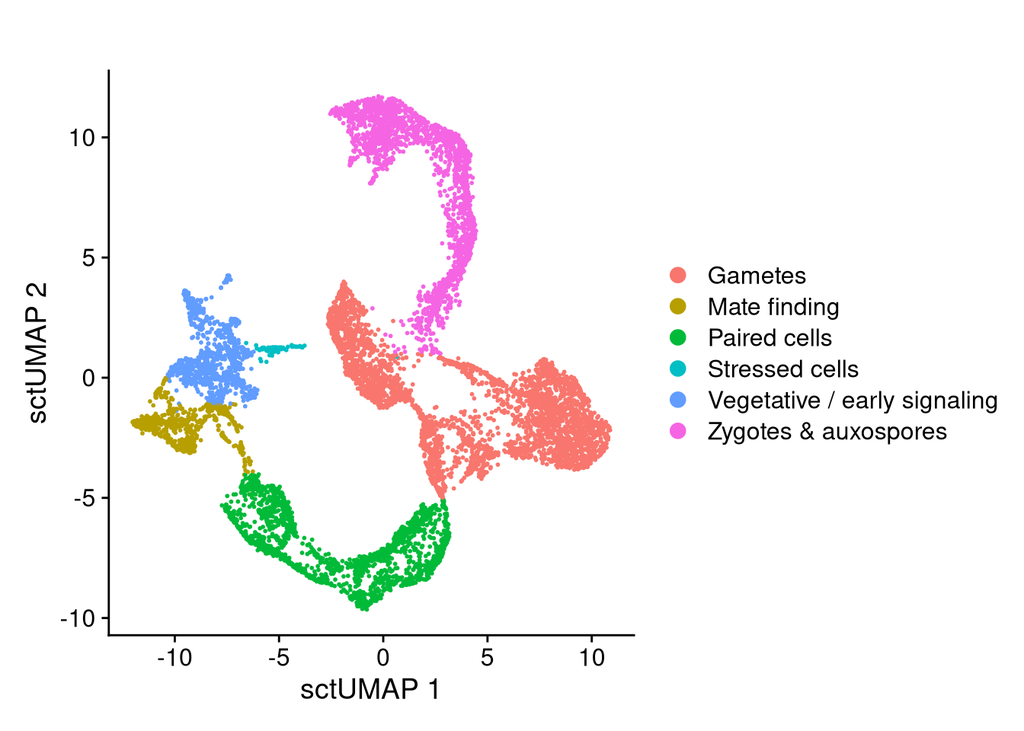

```r
DimPlot(seuratObj, reduction="SCT_umap", group.by = "Cell_type", pt.size=0.22)+ labs(title = "")+xlab("sctUMAP 1")+ylab("sctUMAP 2")
```

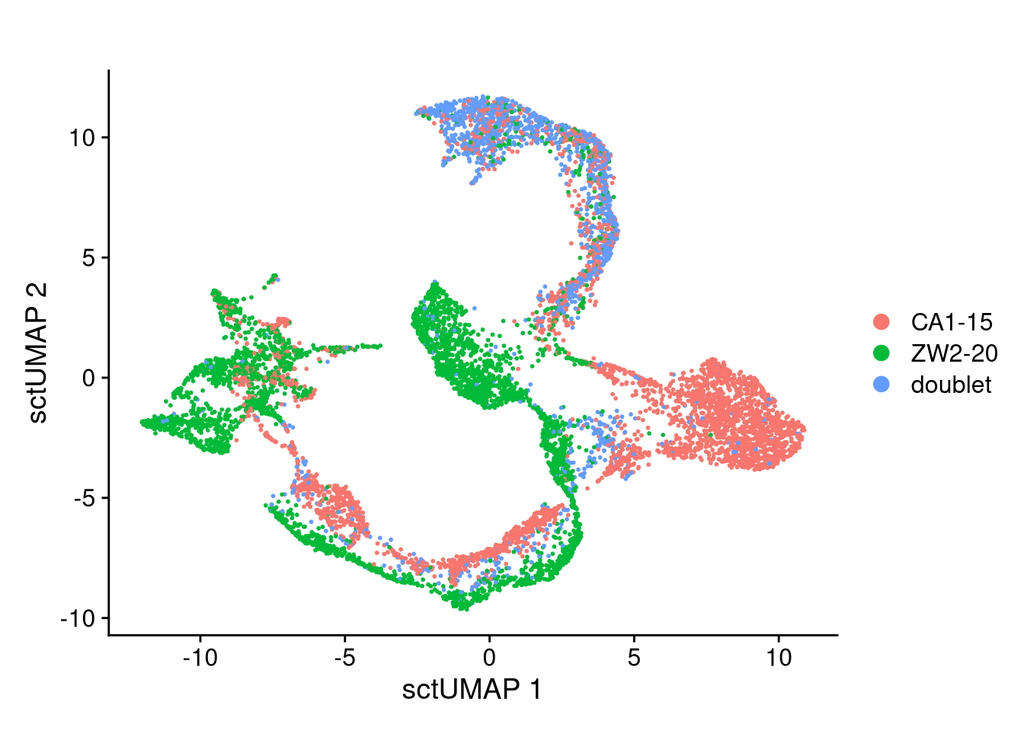

```r
DimPlot(seuratObj, reduction="SCT_umap", group.by = "Genotype", pt.size=0.22)+ labs(title = "")+xlab("sctUMAP 1")+ylab("sctUMAP 2")
```

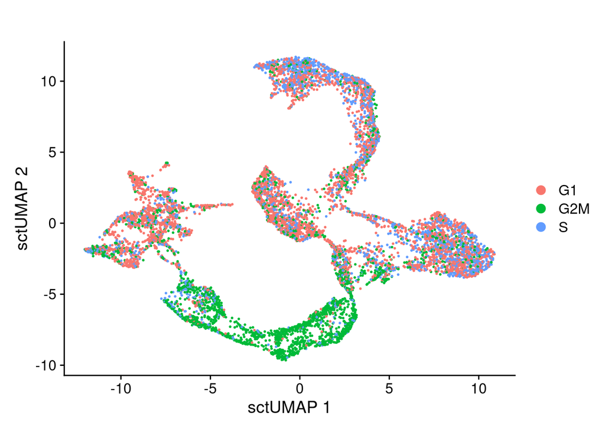

```r
DimPlot(seuratObj, reduction="SCT_umap", group.by = "CellCyclePhase", pt.size=0.22)+ labs(title = "")+xlab("sctUMAP 1")+ylab("sctUMAP 2")
```

## Trajectory inference

### Fit trajectory with Slingshot

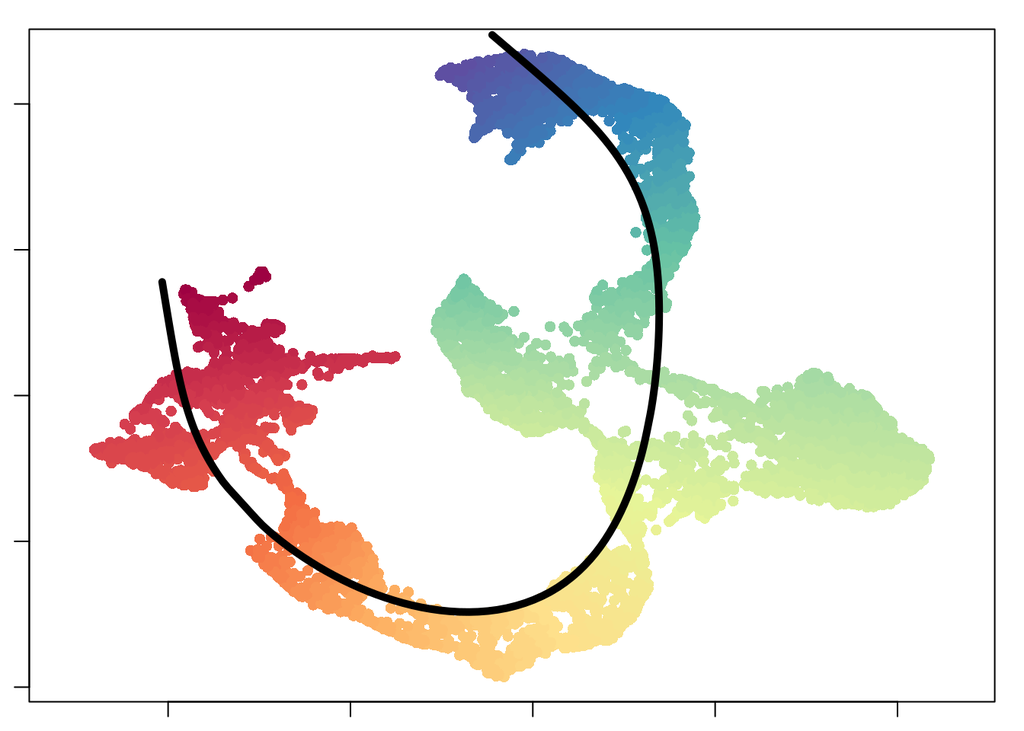

```r
coordinates <- data.frame(seuratObj@reductions$SCT_umap@cell.embeddings[! seuratObj@meta.data$Cluster %in% c(3,2,11,8, 12,13),])
clusters <- seuratObj@meta.data$Cluster[! seuratObj@meta.data$Cluster %in% c(3,2,11, 8,12,13)]

sling <- slingshot(coordinates, clusters,start.clus = '1', end.clus = '16')

coordinates3 <- data.frame(seuratObj@reductions$SCT_umap@cell.embeddings)
pseudotimes <-slingPseudotime( slingshot::predict(sling, coordinates3))
weights <- slingCurveWeights( slingshot::predict(sling, coordinates3))
sling2 <-  slingshot::predict(sling, coordinates3)
colors <- colorRampPalette(brewer.pal(11,'Spectral')[-6])(100)
plotcol <- colors[cut(pseudotimes, breaks=100)]

# pdf(file = "plots/Trajectory_inference/entire_trajectory_pseudotime2.pdf")
par(mar = c(1,1,1,1))
plot(coordinates3, col = plotcol,  pch=16, asp = 0.8, cex = 1)
lines(SlingshotDataSet(sling), lwd=5, col = 'black')
```

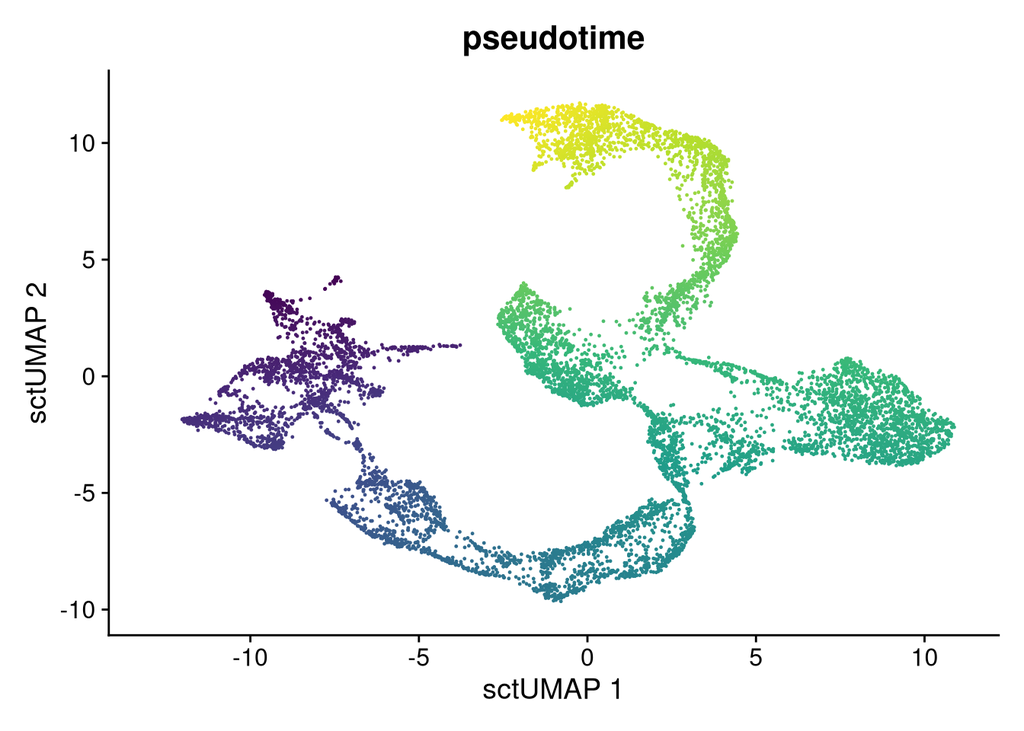

```r
# dev.off()

# Save to Seurat Object
seuratObj@meta.data$pseudotime <- pseudotimes
seuratObj@meta.data$weights <- weights
FeaturePlot(seuratObj, reduction="SCT_umap",  pt.size=0.05, features = "pseudotime") +xlab("sctUMAP 1")+ylab("sctUMAP 2") +scale_color_gradientn(colours = viridis(n = 10)) + theme(legend.position = "none")
```

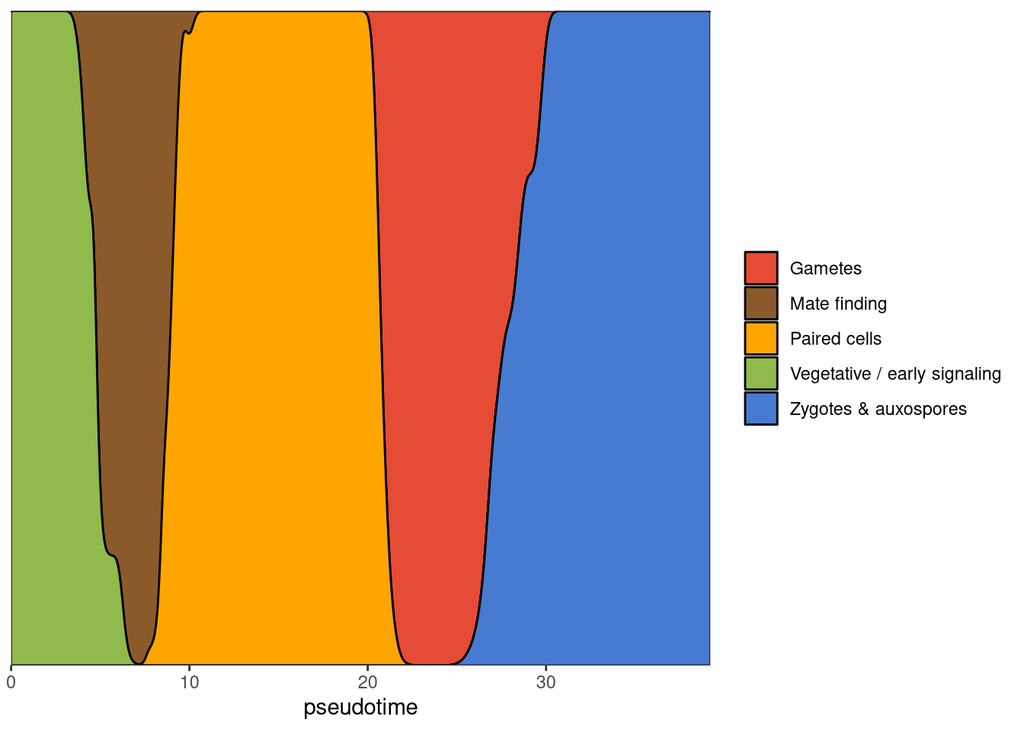

```r
# Cell type composition along pseudotime
celltypecols <- c("#E64B35",  "tan4", "orange", "#90ba4c", "#477bd1")
ggplot() +
  geom_density(aes(x = seuratObj@meta.data$pseudotime[seuratObj@meta.data$Cell_type != "Stressed cells"], fill = seuratObj@meta.data$Cell_type[seuratObj@meta.data$Cell_type != "Stressed cells"]), position="fill") +
  scale_fill_manual(values = celltypecols) +
  theme_bw() +
    theme(panel.grid = element_blank()) +
    scale_x_continuous(expand = c(0, 0)) +
  scale_y_continuous(expand = c(0, 0)) +
  xlab("pseudotime") +
  theme(axis.text.y = element_blank(), axis.title.y = element_blank(), axis.ticks.y = element_blank(), legend.title=element_blank())
```

#### Evaluate number of knots

```{r; eval = FALSE}

counts <- as.matrix(seuratObj@assays$RNA@counts)

icMat <- evaluateK(counts = counts, pseudotime = seuratObj@meta.data$pseudotime, cellWeights = seuratObj@meta.data$weights, nGenes = 100, k = 3:10 )

````
Relative AIC levels off at N=8 --> choose 8 knots

#### Fit generalized additive models (GAMs)

Run shell script at /scripts/associationTest/run_figGAM_cluster.sh

The output is saved in data/save_GAM_8knots.rdata

#### Perform associationtest (TradeSeq)


``` r
load("../data/save_GAM_8knots.rdata") # Fitted GAM smoothers
assoc_test <- associationTest(models = gam, contrastType = "end", l2fc =sqrt(3), nPoints = 14) # npoints = 14 to avoid NAs

# Filtering
# Keep only those 8139 genes that are expressed in at least 50 cells with at least 2 UMIs. Loaded from a separate file for memory control
keepgenes <- as.character(read.table("../data/keep_genes_filtering.txt", header = T)$x)
assoc_test2 <- assoc_test[rownames(assoc_test) %in% keepgenes,] # 8139 kept

assoc_test2$adjP <- p.adjust(assoc_test2$pvalue, "BH")
sum(assoc_test2$adjP < 0.05 & ! is.na(assoc_test2$adjP)) # 3703 associated genes
````

```
## [1] 3703
```

```r
# save(assoc_test2, file =  "../data/association_test2.RData")
```

## Mating type-specific expression

### Test for genes with mating-type-specific expression

```r
seuratMT <- subset(seuratObj, subset = (Consensus_matingtype == "MT+" | Consensus_matingtype == "MT-"))
Idents(seuratMT) <- seuratMT@meta.data$Consensus_matingtype
allmarkers_MT <- FindAllMarkers(object = seuratMT, only.pos = TRUE, logfc.threshold = 3)
table(allmarkers_MT$cluster[allmarkers_MT$p_val_adj < 0.05])
```

```
##
## MT+ MT-
## 111 371
```

```r
sig_MTmarkers <- allmarkers_MT[allmarkers_MT$p_val_adj < 0.05,]
```

### Clustering expression of mating types over pseudotime

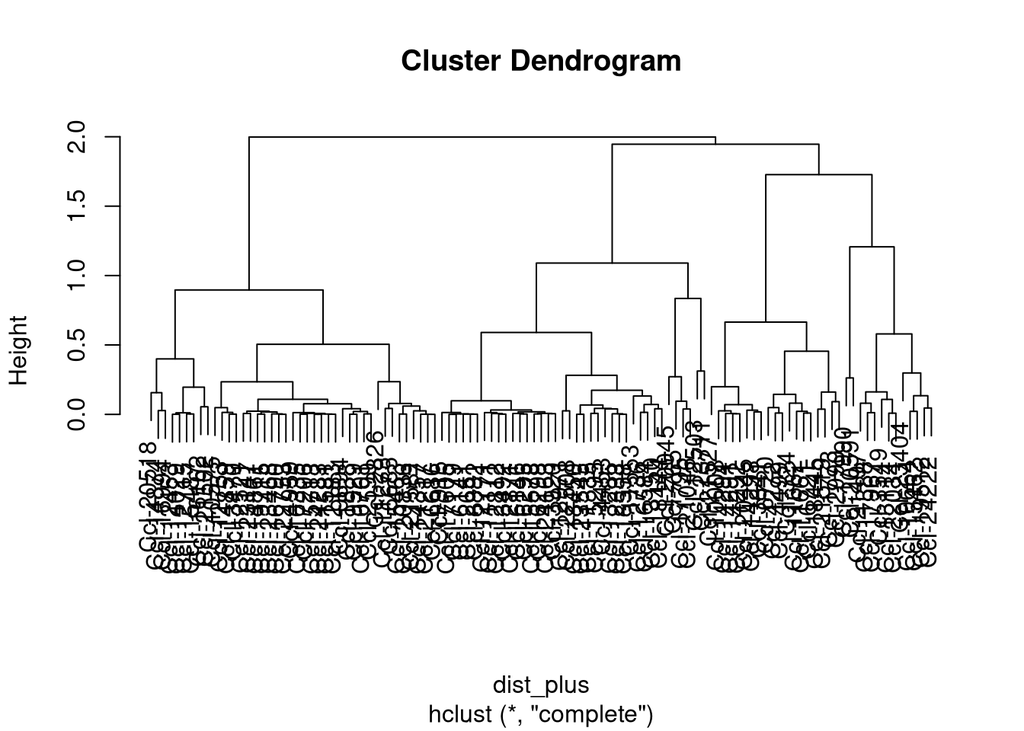

```r
load("../data/predicted_MT_GAMs.RData") # Predicted expression on 60 pseudotime points per mating type
sig_MTmarkers <- read.xlsx("../data/MT_genes_annotation.xlsx", 1)

predicted_plus <- df[df$lineage == "MT+" & df$gene_ID %in% sig_MTmarkers$gene[sig_MTmarkers$cluster == "MT+"],] # Cluster only on the pattern of the "dominant" MT
predicted_min <- df[df$lineage == "MT-" & df$gene_ID %in% sig_MTmarkers$gene[sig_MTmarkers$cluster == "MT-"],] # Cluster only on the pattern of the "dominant" MT

# Clustering the plus genes
k = 4
plus_wide <- spread(predicted_plus[c(1,3,4)], key = "gene_ID", value = "expr")
rownames(plus_wide) <- plus_wide$pseudotime
plus_wide <- plus_wide[-1]
dist_plus <- as.dist(1-cor(plus_wide))
clust_plus <- hclust(dist_plus)
clusters_plus <- cutree(clust_plus, k = k)
plot(clust_plus)
```

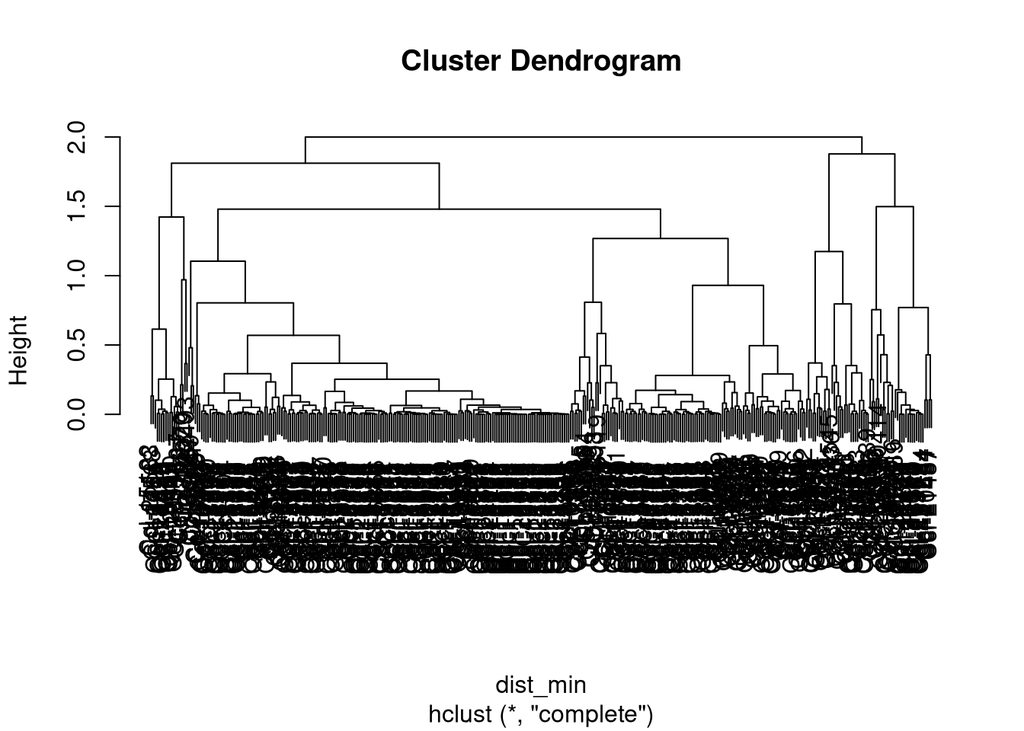

```r
# Clustering the minus genes
min_wide <- spread(predicted_min[c(1,3,4)], key = "gene_ID", value = "expr")
rownames(min_wide) <- min_wide$pseudotime
min_wide <- min_wide[-1]
dist_min <- as.dist(1-cor(min_wide))
clust_min <- hclust(dist_min)
clusters_min <- cutree(clust_min, k = k)
plot(clust_min)
```

### Define function to plot genes over mating type-specific pseudotime

```r
plotMT_GAM_small <- function(gene_IDs){
  df2 <- df[df$gene_ID %in% gene_IDs,]
  ggplot(df2) +
  geom_line(aes(x = pseudotime, y = expr, colour = lineage, group = interaction(lineage,gene_ID)), size = 0.2) +
      scale_colour_manual(values = c("#439fb7", "#eb6349")) +
    new_scale_colour() +
  stat_summary(aes(x = pseudotime, y = expr, colour = lineage), geom = "line", fun = "mean", size = 3) +
          scale_colour_manual(values = c("#368195", "#d03517")) +
  ylab("Relative expression") +
  xlab("Pseudotime") +
  theme_bw() +
    theme(panel.grid = element_blank(), panel.background = element_rect(fill = "grey90")) +
 scale_y_continuous(limits = c(0, NA)) +
    scale_y_continuous(expand = expansion( mult = c(0, .05)))
}
```

### Extract and plot clusters from the hierarchical clustering

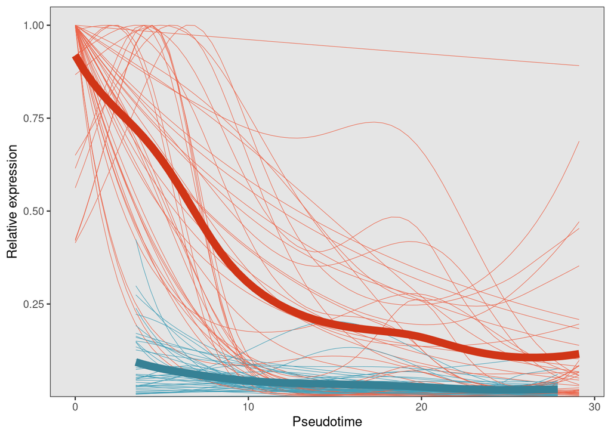

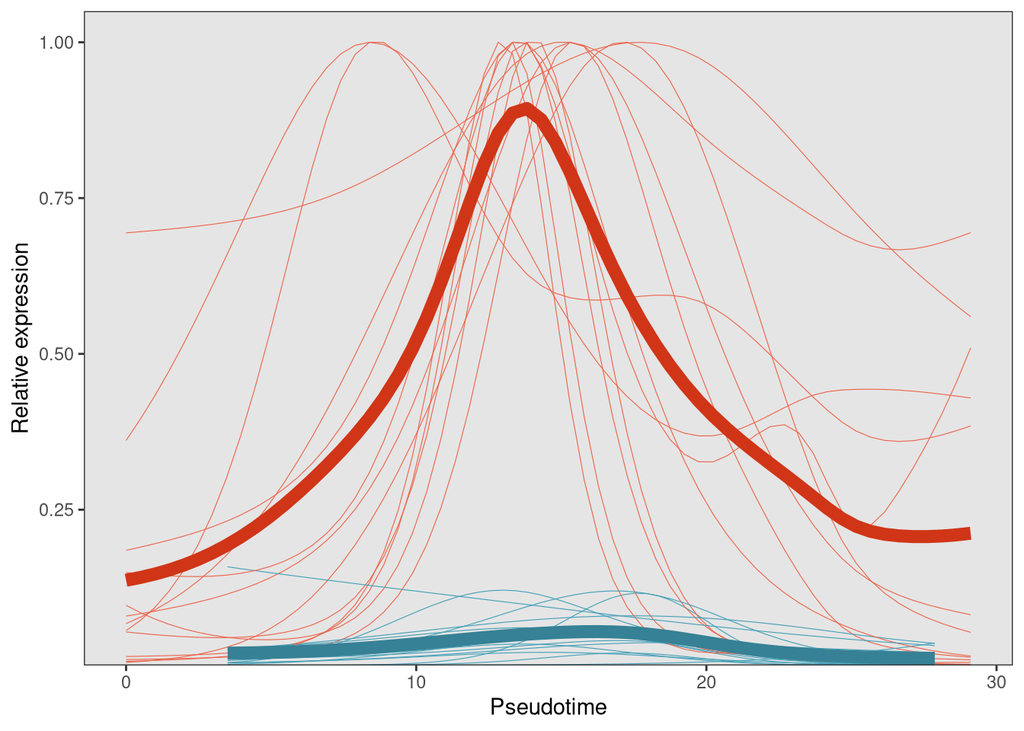

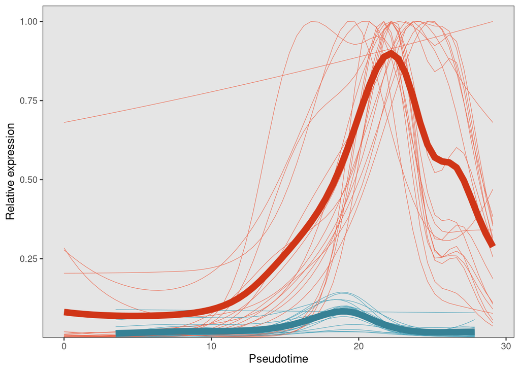

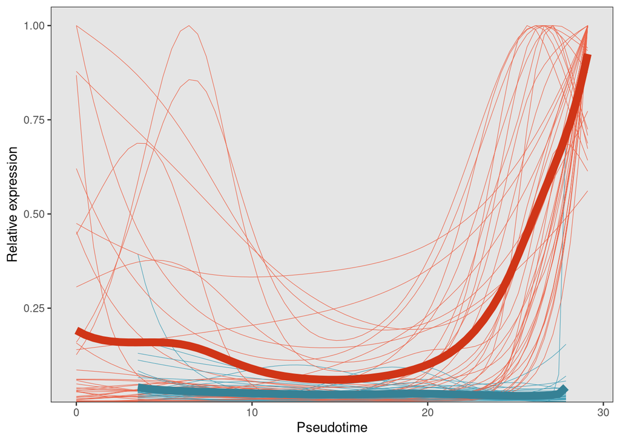

```r
plotlist <- list()

clusters_plus <- cutree(clust_plus, k = k)
clusters_plus[clusters_plus == 1] <- "3Midlate"
clusters_plus[clusters_plus == 2] <- "1Early"
clusters_plus[clusters_plus == 3] <- "2Middle"
clusters_plus[clusters_plus == 4] <- "4Late"

for (i in c("1Early", "2Middle", "3Midlate", "4Late")) {
  plot(plotMT_GAM_small(names(clusters_plus)[clusters_plus == i]) + theme(legend.position = "none"))
}
```

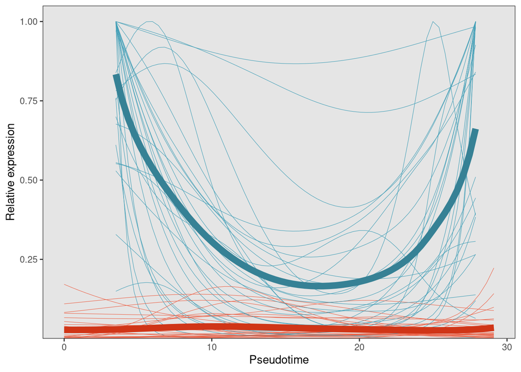

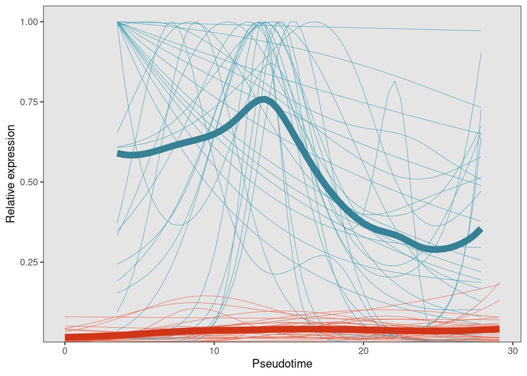

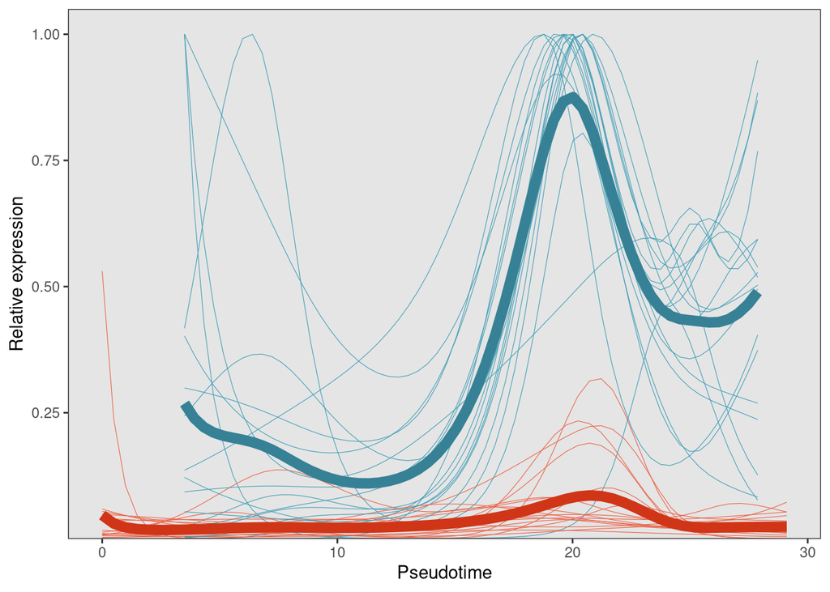

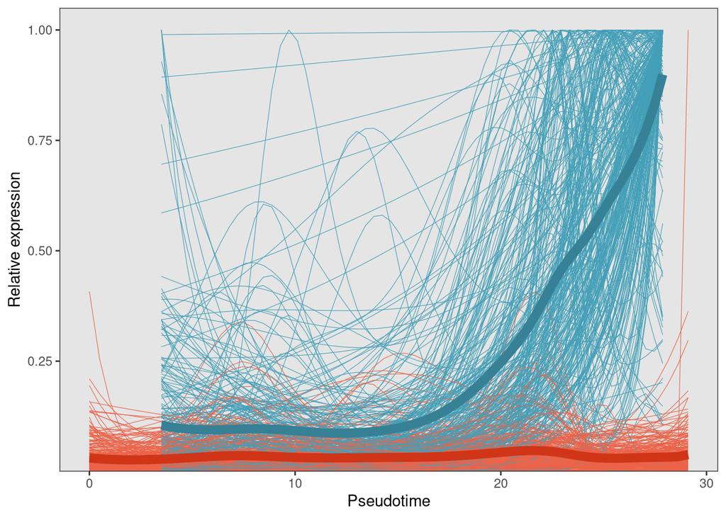

```r
clusters_min <- cutree(clust_min, k = k)
clusters_min[clusters_min == 1] <- "4Late"
clusters_min[clusters_min == 2] <- "1Early"
clusters_min[clusters_min == 3] <- "2Middle"
clusters_min[clusters_min == 4] <- "3Midlate"

for (i in c("1Early", "2Middle", "3Midlate", "4Late")) {
  plot(plotMT_GAM_small(names(clusters_min)[clusters_min == i]) + theme(legend.position = "none"))
}
```

## Gene regulation

### Identify transcription factors (TFs) associated with pseudotime

```r
# First get association test data for all putative TFs (i.e. those with DNA binding domains)
putativeTFs <- read.delim("../data/C_closterium_TFs_added.txt")
load("../data/association_test2.RData")
associatedgenes <- rownames(assoc_test2[assoc_test2$adjP < 1e-5 & !is.na(assoc_test2$adjP),])
associatedTFs <- putativeTFs[putativeTFs$gene %in% associatedgenes,] # 58 associated putative TFs

# Filter TFs: Because this figure is a crucial starting point to pinpoint the TFs involved in sex, putative TFs were manually curated
checkTFs <- read.xlsx("../data/manual_curation_associatedTFs.xlsx")
associatedTFs_checked <- associatedTFs[associatedTFs$gene %in% checkTFs$gene[checkTFs$conclusion == "TF"],] # 33 bona fide associated TFs
associatedTFs_checked$TF <- unlist(lapply(associatedTFs_checked$gene, function(x) checkTFs$newname[checkTFs$gene == x]))
```

### Plot TF ridgeline plots

```r
pal_pseudotimes <- paletteer_d("ggthemes::Tableau_20")[seq(1,19, by = 2)]
genepseudo <- read.delim("../data/gene_ordering_pseudotime.txt")$x # this file is sorted reversely (auxospores first, then ending with vegetative)!

counts <- as.matrix(seuratObj@assays$RNA@counts)
```

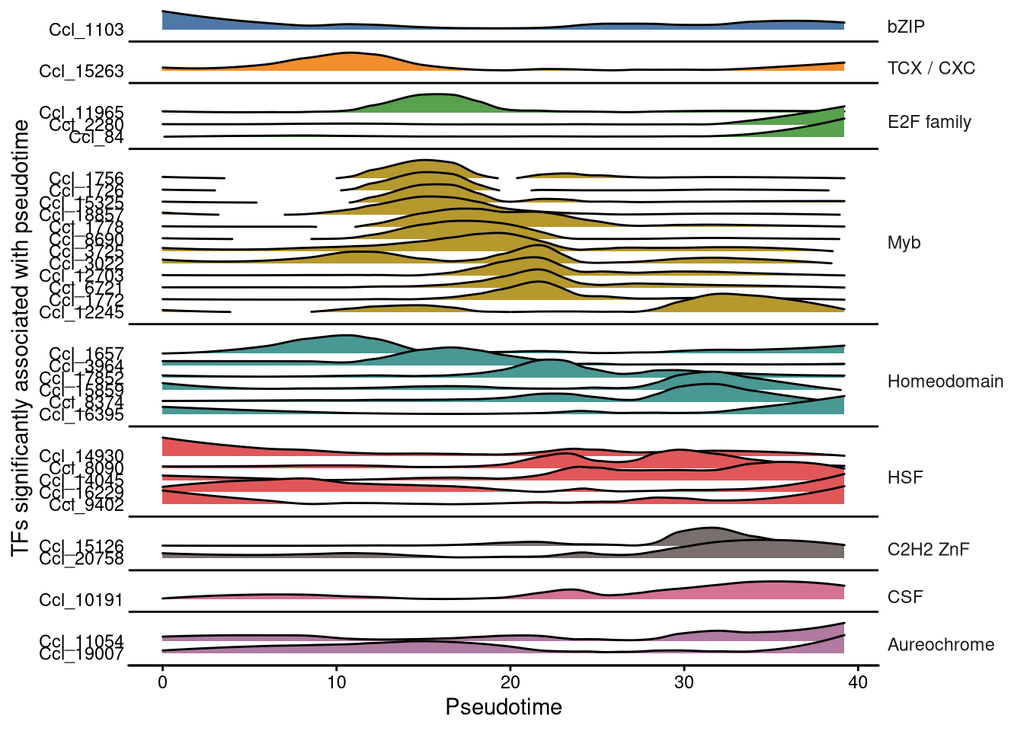

```r
counts <- as.data.frame(counts)

plot_ridges <- function(df) {
  gene_IDs <- df$gene
  selectcounts <- counts[rownames(counts) %in% gene_IDs,]
  selectcounts$gene_ID  <- rownames(selectcounts)
  selectcounts$gene_ID <- factor(selectcounts$gene_ID, levels = genepseudo)
  selectcounts$family <- unlist(lapply(selectcounts$gene_ID, function(x) df$TF[df$gene == x]))
  selectL <- gather(selectcounts, 1:8674, key = "cell", value = "UMIs" )
  selectL$pseudotime <- rep(seuratObj@meta.data$pseudotime, each = length(gene_IDs) )

  for (gene_ID in unique(selectL$gene_ID)){
  x <- predict(loess(selectL$UMIs[selectL$gene_ID == gene_ID]~selectL$pseudotime[selectL$gene_ID == gene_ID], span = 0.3))
  selectL$smooth[selectL$gene_ID == gene_ID] <- x/max(x)
  }

  genepseudo2 <- unlist(lapply(genepseudo, function(x) gsub("-", "_", x)))
  selectL$gene <- unlist(lapply(selectL$gene_ID, function(x) gsub("-", "_", x)))
  selectL$gene <- factor(selectL$gene, levels = genepseudo2)

  ggplot(selectL)+
    geom_hline(yintercept = 0) +
    geom_ridgeline(aes(x = pseudotime, y = gene , height = smooth, fill = family), scale = 1.5) +
    ylab("TFs significantly associated with pseudotime") +
    xlab("Pseudotime") +
    facet_grid(family ~ ., space = "free", scales = "free") +
    scale_fill_manual(values = pal_pseudotimes) +
            theme_classic() +
        theme(strip.text.y = element_text(angle = 0, hjust = 0), strip.background = element_blank(), legend.position = "none", axis.line.y = element_blank(), axis.ticks.y = element_blank()) +
    scale_y_discrete(expand = c(0.05, 0)) +
  coord_cartesian(clip = "off")

  }

associatedTFs_checked$TF <- factor(associatedTFs_checked$TF, levels = c("bZIP", "TCX / CXC", "E2F family", "Myb", "Homeodomain", "HSF", "C2H2 ZnF", "CSF", "Aureochrome"))

plot_ridges(associatedTFs_checked)
```